# Solution_FE_Project

## Exploratory Data Quality Report

```python
#Import necessary libraries
%matplotlib inline
import numpy as np
import pandas as pd
import matplotlib.pyplot as plt
import seaborn as sns
import warnings
warnings.filterwarnings("ignore")
```

```python
df1 = pd.read_csv("concrete.csv")  # Read the data regarding customer attributes
```

```python
df1.head(10)
```

|  | cement | slag | ash | water | superplastic | coarseagg | fineagg | age | strength |
| --- | --- | --- | --- | --- | --- | --- | --- | --- | --- |
| 0 | 141.3 | 212.0 | 0.0 | 203.5 | 0.0 | 971.8 | 748.5 | 28 | 29.89 |
| 1 | 168.9 | 42.2 | 124.3 | 158.3 | 10.8 | 1080.8 | 796.2 | 14 | 23.51 |
| 2 | 250.0 | 0.0 | 95.7 | 187.4 | 5.5 | 956.9 | 861.2 | 28 | 29.22 |
| 3 | 266.0 | 114.0 | 0.0 | 228.0 | 0.0 | 932.0 | 670.0 | 28 | 45.85 |
| 4 | 154.8 | 183.4 | 0.0 | 193.3 | 9.1 | 1047.4 | 696.7 | 28 | 18.29 |
| 5 | 255.0 | 0.0 | 0.0 | 192.0 | 0.0 | 889.8 | 945.0 | 90 | 21.86 |
| 6 | 166.8 | 250.2 | 0.0 | 203.5 | 0.0 | 975.6 | 692.6 | 7 | 15.75 |
| 7 | 251.4 | 0.0 | 118.3 | 188.5 | 6.4 | 1028.4 | 757.7 | 56 | 36.64 |
| 8 | 296.0 | 0.0 | 0.0 | 192.0 | 0.0 | 1085.0 | 765.0 | 28 | 21.65 |
| 9 | 155.0 | 184.0 | 143.0 | 194.0 | 9.0 | 880.0 | 699.0 | 28 | 28.99 |

```python
# shape
df1.shape
```

```
(1030, 9)
```

```python
df1.dtypes
```

```
cement          float64
slag            float64
ash             float64
water           float64
superplastic    float64
coarseagg       float64
fineagg         float64
age               int64
strength        float64
dtype: object
```

### 1.Univariate analysis

```python
# name, range of values observed, central values (mean and median), standard deviation and quartiles
pd.concat([df1.describe(),pd.DataFrame(df1.median() , columns = ["median"] ).T])
```

|  | cement | slag | ash | water | superplastic | coarseagg | fineagg | age | strength |
| --- | --- | --- | --- | --- | --- | --- | --- | --- | --- |
| count | 1030.000000 | 1030.000000 | 1030.000000 | 1030.000000 | 1030.000000 | 1030.000000 | 1030.000000 | 1030.000000 | 1030.000000 |
| mean | 281.167864 | 73.895825 | 54.188350 | 181.567282 | 6.204660 | 972.918932 | 773.580485 | 45.662136 | 35.817961 |
| std | 104.506364 | 86.279342 | 63.997004 | 21.354219 | 5.973841 | 77.753954 | 80.175980 | 63.169912 | 16.705742 |
| min | 102.000000 | 0.000000 | 0.000000 | 121.800000 | 0.000000 | 801.000000 | 594.000000 | 1.000000 | 2.330000 |
| 25% | 192.375000 | 0.000000 | 0.000000 | 164.900000 | 0.000000 | 932.000000 | 730.950000 | 7.000000 | 23.710000 |
| 50% | 272.900000 | 22.000000 | 0.000000 | 185.000000 | 6.400000 | 968.000000 | 779.500000 | 28.000000 | 34.445000 |
| 75% | 350.000000 | 142.950000 | 118.300000 | 192.000000 | 10.200000 | 1029.400000 | 824.000000 | 56.000000 | 46.135000 |
| max | 540.000000 | 359.400000 | 200.100000 | 247.000000 | 32.200000 | 1145.000000 | 992.600000 | 365.000000 | 82.600000 |
| median | 272.900000 | 22.000000 | 0.000000 | 185.000000 | 6.400000 | 968.000000 | 779.500000 | 28.000000 | 34.445000 |

### observation:

#### Concentrations of slag , ash are heavily right skewed.

```python
 # missing values, outliers, duplicates
df1.isna().sum()
df1.isnull().sum()
```

[output not shown]

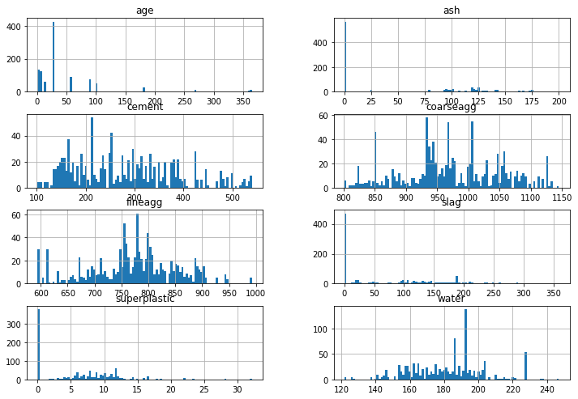

```python
# Histplots to get summary overall distribution
columns = list(df1)[0:-1] # Excluding Outcome column which has only

df1[columns].hist(stacked=True, bins=100, figsize=(12,30), layout=(14,2));
```

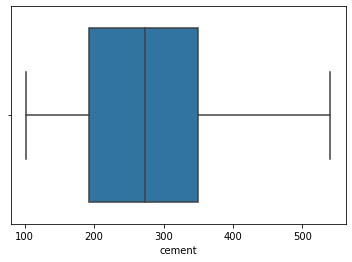

```python
# Boxplots to determine outliers and distribution

sns.boxplot(df1['cement'])
```

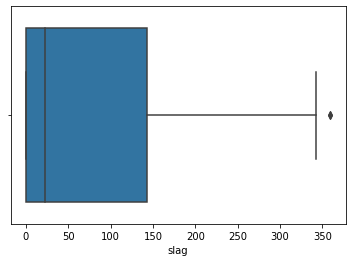

```python
sns.boxplot(df1['slag'])
```

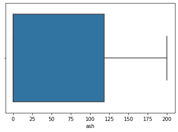

```python
sns.boxplot(df1['ash'])
```

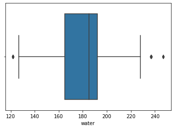

```python
sns.boxplot(df1['water'])
```

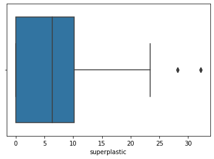

```python
sns.boxplot(df1['superplastic'])
```

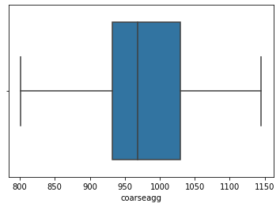

```python
sns.boxplot(df1['coarseagg'])
```

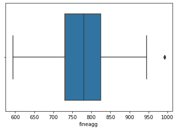

```python
sns.boxplot(df1['fineagg'])
```

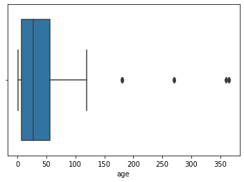

```python
sns.boxplot(df1['age'])
```

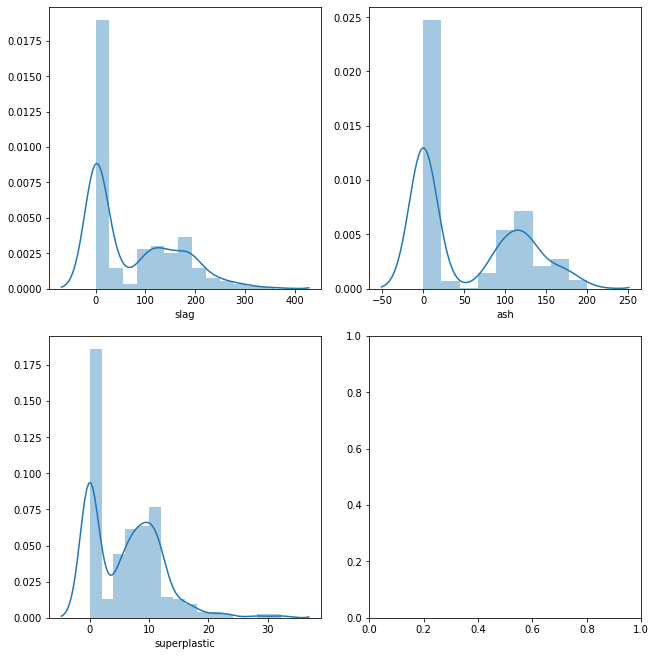

```python
# Distplot to get the distribution tails for skewed distributions

lst = ['slag','ash','superplastic']

fig, axarr = plt.subplots(nrows=2, ncols=2,
                        figsize=(9, 9), constrained_layout=True)
for i, p in enumerate(lst):
      row = i // 2;
      pos = i%2;
      sns.distplot(df1[p],ax=axarr[row][pos])
```

### Observation from Univariate Analysis:

#### - Age has most outliers compared to other features.

### 2. Bivariate Analysis

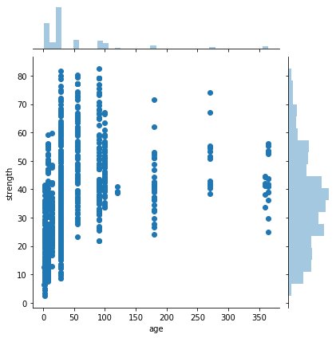

```python
# plots to get effect of each content on concrete's strength
sns.jointplot(y="strength", x="age", data=df1);
```

#### From the above graph , we can categorize age in to bins ( as there is more discrete relation and use age as heuristic paramter in other parameter relationship to undersand them better

```python
### Process age parameter in to bins

#df1['age_binned']=pd.cut(x=df1['age'], bins=[0,50,100,150,200,250,300,350,400])
df1['age_binned']=pd.cut(x=df1['age'], bins=[0,90,180,270,360,400])
df1['age_binned']
```

```
0          (0, 90]
1          (0, 90]
2          (0, 90]
3          (0, 90]
4          (0, 90]
           ...
1025       (0, 90]
1026       (0, 90]
1027       (0, 90]
1028    (180, 270]
1029       (0, 90]
Name: age_binned, Length: 1030, dtype: category
Categories (5, interval[int64]): [(0, 90] < (90, 180] < (180, 270] < (270, 360] < (360, 400]]
```

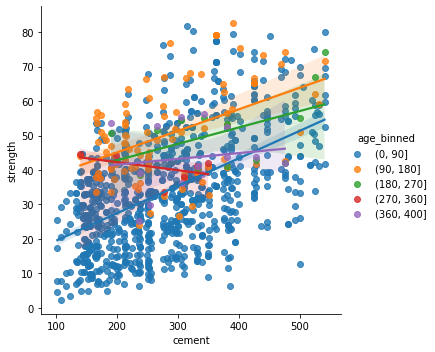

```python
sns.lmplot(y="strength", x="cement", hue="age_binned",data=df1);
```

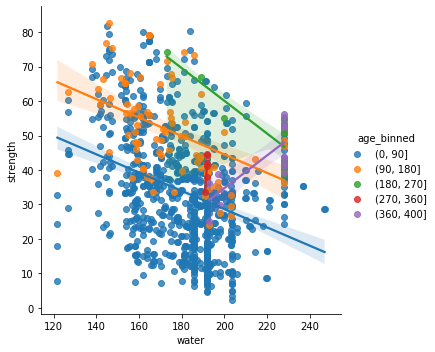

```python
sns.lmplot(y="strength", x="water", hue="age_binned",data=df1);
```

#### From the above graph we see that there is a positive linear relationship between cement and the strength and negative relationship between water content and strength generally.

#### Therefore lets see how cement to water ratio impacts the strength

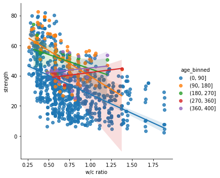

```python
df1['w/c ratio'] = df1['water']/df1['cement']
sns.lmplot(y="strength", x="w/c ratio", hue="age_binned",data=df1);
```

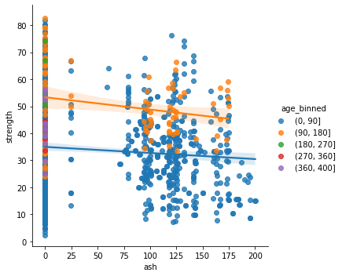

```python
sns.lmplot(y="strength", x="ash", hue="age_binned", data=df1);
```

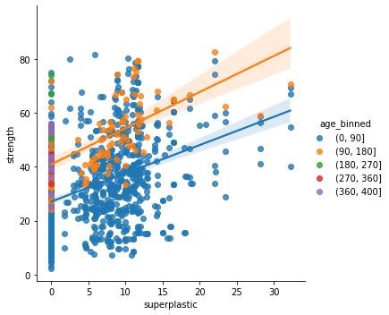

```python
sns.lmplot(y="strength", x="superplastic", hue="age_binned", data=df1);
```

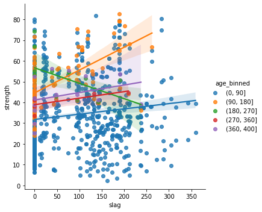

```python
sns.lmplot(y="strength", x="slag", hue="age_binned", data=df1);
```

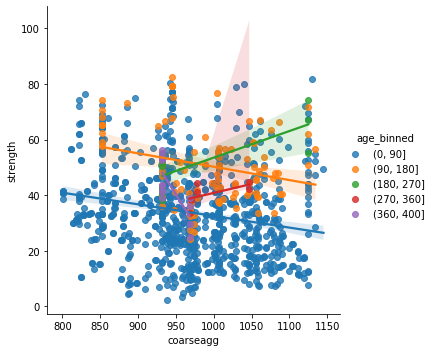

```python
sns.lmplot(y="strength", x="coarseagg", hue="age_binned", data=df1);
```

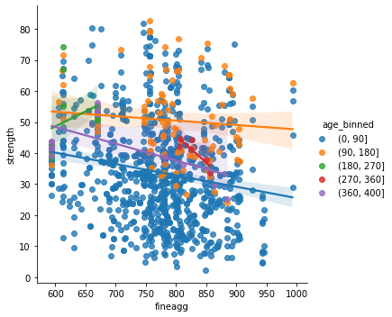

```python
sns.lmplot(y="strength", x="fineagg", hue="age_binned", data=df1);
```

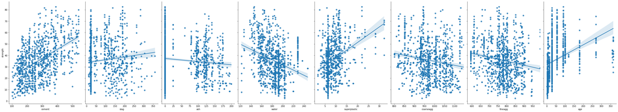

```python
sns.pairplot(df1, x_vars=['cement', 'slag', 'ash','water','superplastic', 'coarseagg', 'fineagg','age'],
             y_vars='strength', size=7, aspect=0.7, kind='reg')
#sns.pairplot(df1[['cement', 'slag', 'ash','water','superplastic', 'coarseagg', 'fineagg','age','strength']]);
```

## 3. Feature Engineering

### Feature Extraction:

#### From the univariate and bivariate analysis, Following can be done:

#### - Looking the impact of aging more precisely when binned needs to be convered to a categorical variable with labels in quarters.

#### - The skewness of graphs for Slag , Ash and Super plastic concentrations can be removed by replacing zero values with mena/median for better predictions.

#### - Instead of treating cement and water as seperate parmaters , water cement ratio can be used in the analysis ( the W/C ratio is already added as part of the Bivariate anlysis)

```python
# Converting age bins to catorical value
# aging as categorical variable should be ordered as well

bin_labels_5 = [1, 2, 3, 4, 5]

df1['age_binned']=pd.cut(x=df1['age'], bins=[0,90,180,270,360,400],
                        labels=bin_labels_5)

df1.head(10)
```

|  | cement | slag | ash | water | superplastic | coarseagg | fineagg | age | strength | age_binned | w/c ratio |
| --- | --- | --- | --- | --- | --- | --- | --- | --- | --- | --- | --- |
| 0 | 141.3 | 212.0 | 0.0 | 203.5 | 0.0 | 971.8 | 748.5 | 28 | 29.89 | 1 | 1.440198 |
| 1 | 168.9 | 42.2 | 124.3 | 158.3 | 10.8 | 1080.8 | 796.2 | 14 | 23.51 | 1 | 0.937241 |
| 2 | 250.0 | 0.0 | 95.7 | 187.4 | 5.5 | 956.9 | 861.2 | 28 | 29.22 | 1 | 0.749600 |
| 3 | 266.0 | 114.0 | 0.0 | 228.0 | 0.0 | 932.0 | 670.0 | 28 | 45.85 | 1 | 0.857143 |
| 4 | 154.8 | 183.4 | 0.0 | 193.3 | 9.1 | 1047.4 | 696.7 | 28 | 18.29 | 1 | 1.248708 |
| 5 | 255.0 | 0.0 | 0.0 | 192.0 | 0.0 | 889.8 | 945.0 | 90 | 21.86 | 1 | 0.752941 |
| 6 | 166.8 | 250.2 | 0.0 | 203.5 | 0.0 | 975.6 | 692.6 | 7 | 15.75 | 1 | 1.220024 |
| 7 | 251.4 | 0.0 | 118.3 | 188.5 | 6.4 | 1028.4 | 757.7 | 56 | 36.64 | 1 | 0.749801 |
| 8 | 296.0 | 0.0 | 0.0 | 192.0 | 0.0 | 1085.0 | 765.0 | 28 | 21.65 | 1 | 0.648649 |
| 9 | 155.0 | 184.0 | 143.0 | 194.0 | 9.0 | 880.0 | 699.0 | 28 | 28.99 | 1 | 1.251613 |

```python
 # Replacing zero values with me

df1=df1.replace({'slag': {0: df1['slag'].median(skipna=True)}})
df1=df1.replace({'ash': {0: df1['ash'].median(skipna=True)}})
df1=df1.replace({'superplastic': {0: df1['superplastic'].median(skipna=True)}})
df1.head(10)
```

|  | cement | slag | ash | water | superplastic | coarseagg | fineagg | age | strength | age_binned | w/c ratio |
| --- | --- | --- | --- | --- | --- | --- | --- | --- | --- | --- | --- |
| 0 | 141.3 | 212.0 | 0.0 | 203.5 | 6.4 | 971.8 | 748.5 | 28 | 29.89 | 1 | 1.440198 |
| 1 | 168.9 | 42.2 | 124.3 | 158.3 | 10.8 | 1080.8 | 796.2 | 14 | 23.51 | 1 | 0.937241 |
| 2 | 250.0 | 22.0 | 95.7 | 187.4 | 5.5 | 956.9 | 861.2 | 28 | 29.22 | 1 | 0.749600 |
| 3 | 266.0 | 114.0 | 0.0 | 228.0 | 6.4 | 932.0 | 670.0 | 28 | 45.85 | 1 | 0.857143 |
| 4 | 154.8 | 183.4 | 0.0 | 193.3 | 9.1 | 1047.4 | 696.7 | 28 | 18.29 | 1 | 1.248708 |
| 5 | 255.0 | 22.0 | 0.0 | 192.0 | 6.4 | 889.8 | 945.0 | 90 | 21.86 | 1 | 0.752941 |
| 6 | 166.8 | 250.2 | 0.0 | 203.5 | 6.4 | 975.6 | 692.6 | 7 | 15.75 | 1 | 1.220024 |
| 7 | 251.4 | 22.0 | 118.3 | 188.5 | 6.4 | 1028.4 | 757.7 | 56 | 36.64 | 1 | 0.749801 |
| 8 | 296.0 | 22.0 | 0.0 | 192.0 | 6.4 | 1085.0 | 765.0 | 28 | 21.65 | 1 | 0.648649 |
| 9 | 155.0 | 184.0 | 143.0 | 194.0 | 9.0 | 880.0 | 699.0 | 28 | 28.99 | 1 | 1.251613 |

```python
# Normalizing the distribution of Slag , ash and super plastic
print(df1['ash'].quantile(0.10))
print(df1['ash'].quantile(0.90))
print(df1['slag'].quantile(0.10))
print(df1['slag'].quantile(0.90))
print(df1['superplastic'].quantile(0.10))
print(df1['superplastic'].quantile(0.90))
```

```
0.0
141.06
22.0
192.0
5.8
12.21
```

```
0.39102383068892
```

```
{'whiskers': [<matplotlib.lines.Line2D at 0x7fda7a568610>,
 'caps': [<matplotlib.lines.Line2D at 0x7fda7a945e90>,
 'boxes': [<matplotlib.lines.Line2D at 0x7fda7a945290>],
 'medians': [<matplotlib.lines.Line2D at 0x7fda689d8790>],
 'fliers': [<matplotlib.lines.Line2D at 0x7fda7a941690>],
 'means': []}
```

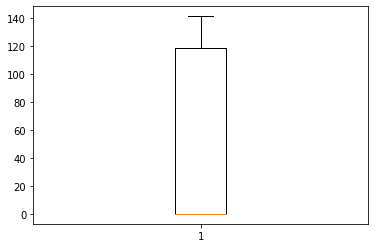

```python
df1["ash_norm"] = np.where(df1["ash"] < 0.0, 0.0,df1["ash"])
df1["ash_norm"] = np.where(df1["ash"] > 141.06, 141.06,df1["ash"])
# check the skew value again
print(df1["ash_norm"].skew())
plt.boxplot(df1["ash_norm"])
```

```
0.5863183812397404
```

```
{'whiskers': [<matplotlib.lines.Line2D at 0x7fda7a84b210>,
 'caps': [<matplotlib.lines.Line2D at 0x7fda7a6408d0>,
 'boxes': [<matplotlib.lines.Line2D at 0x7fda7a86f2d0>],
 'medians': [<matplotlib.lines.Line2D at 0x7fda7a8559d0>],
 'fliers': [<matplotlib.lines.Line2D at 0x7fda7a6496d0>],
 'means': []}
```

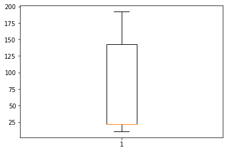

```python
df1["slag_norm"] = np.where(df1["slag"] < 22.0, 22.0,df1["slag"])
df1["slag_norm"] = np.where(df1["slag"] > 192.0, 192.0,df1["slag"])
# check the skew value again
print(df1["slag_norm"].skew())
plt.boxplot(df1["slag_norm"])
```

```
0.3638655589219542
```

```
{'whiskers': [<matplotlib.lines.Line2D at 0x7fda7ea83cd0>,
 'caps': [<matplotlib.lines.Line2D at 0x7fda69170790>,
 'boxes': [<matplotlib.lines.Line2D at 0x7fda7ea83c90>],
 'medians': [<matplotlib.lines.Line2D at 0x7fda66b71e50>],
 'fliers': [<matplotlib.lines.Line2D at 0x7fda7ea98f50>],
 'means': []}
```

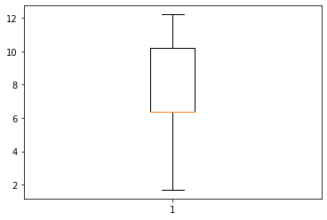

```python
df1["superplastic_norm"] = np.where(df1["superplastic"] < 5.8, 5.8,df1["superplastic"])
df1["superplastic_norm"] = np.where(df1["superplastic"] > 12.21, 12.21,df1["superplastic"])
# check the skew value again
print(df1["superplastic_norm"].skew())
plt.boxplot(df1["superplastic_norm"])
```

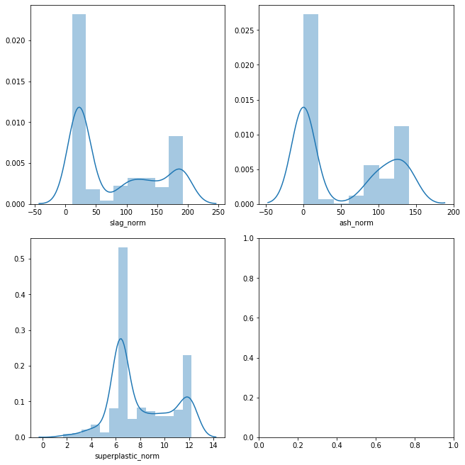

```python
# Distplot to get the distribution tails for skewed distributions

lst = ['slag_norm','ash_norm','superplastic_norm']

fig, axarr = plt.subplots(nrows=2, ncols=2,
                        figsize=(9, 9), constrained_layout=True)
for i, p in enumerate(lst):
      row = i // 2;
      pos = i%2;
      sns.distplot(df1[p],ax=axarr[row][pos])
```

#### - We see from the above graph that normalizing these paramaters doesnt really change the distribution.

#### - Water to cement ratio is already done bivariate analysis

### Getting the data model ready and do a train test split.

```python
df1.head(10)
```

|  | cement | slag | ash | water | superplastic | coarseagg | fineagg | age | strength | age_binned | w/c ratio | ash_norm | slag_norm | superplastic_norm |
| --- | --- | --- | --- | --- | --- | --- | --- | --- | --- | --- | --- | --- | --- | --- |
| 0 | 141.3 | 212.0 | 0.0 | 203.5 | 6.4 | 971.8 | 748.5 | 28 | 29.89 | 1 | 1.440198 | 0.00 | 192.0 | 6.4 |
| 1 | 168.9 | 42.2 | 124.3 | 158.3 | 10.8 | 1080.8 | 796.2 | 14 | 23.51 | 1 | 0.937241 | 124.30 | 42.2 | 10.8 |
| 2 | 250.0 | 22.0 | 95.7 | 187.4 | 5.5 | 956.9 | 861.2 | 28 | 29.22 | 1 | 0.749600 | 95.70 | 22.0 | 5.5 |
| 3 | 266.0 | 114.0 | 0.0 | 228.0 | 6.4 | 932.0 | 670.0 | 28 | 45.85 | 1 | 0.857143 | 0.00 | 114.0 | 6.4 |
| 4 | 154.8 | 183.4 | 0.0 | 193.3 | 9.1 | 1047.4 | 696.7 | 28 | 18.29 | 1 | 1.248708 | 0.00 | 183.4 | 9.1 |
| 5 | 255.0 | 22.0 | 0.0 | 192.0 | 6.4 | 889.8 | 945.0 | 90 | 21.86 | 1 | 0.752941 | 0.00 | 22.0 | 6.4 |
| 6 | 166.8 | 250.2 | 0.0 | 203.5 | 6.4 | 975.6 | 692.6 | 7 | 15.75 | 1 | 1.220024 | 0.00 | 192.0 | 6.4 |
| 7 | 251.4 | 22.0 | 118.3 | 188.5 | 6.4 | 1028.4 | 757.7 | 56 | 36.64 | 1 | 0.749801 | 118.30 | 22.0 | 6.4 |
| 8 | 296.0 | 22.0 | 0.0 | 192.0 | 6.4 | 1085.0 | 765.0 | 28 | 21.65 | 1 | 0.648649 | 0.00 | 22.0 | 6.4 |
| 9 | 155.0 | 184.0 | 143.0 | 194.0 | 9.0 | 880.0 | 699.0 | 28 | 28.99 | 1 | 1.251613 | 141.06 | 184.0 | 9.0 |

```python
# dropping columns which are already normalized or converted to ordered categories
data = df1.drop(['cement','slag_norm','ash_norm','water','superplastic_norm','age_binned'],axis=1)
data.head(10)
```

|  | slag | ash | superplastic | coarseagg | fineagg | age | strength | w/c ratio |
| --- | --- | --- | --- | --- | --- | --- | --- | --- |
| 0 | 212.0 | 0.0 | 6.4 | 971.8 | 748.5 | 28 | 29.89 | 1.440198 |
| 1 | 42.2 | 124.3 | 10.8 | 1080.8 | 796.2 | 14 | 23.51 | 0.937241 |
| 2 | 22.0 | 95.7 | 5.5 | 956.9 | 861.2 | 28 | 29.22 | 0.749600 |
| 3 | 114.0 | 0.0 | 6.4 | 932.0 | 670.0 | 28 | 45.85 | 0.857143 |
| 4 | 183.4 | 0.0 | 9.1 | 1047.4 | 696.7 | 28 | 18.29 | 1.248708 |
| 5 | 22.0 | 0.0 | 6.4 | 889.8 | 945.0 | 90 | 21.86 | 0.752941 |
| 6 | 250.2 | 0.0 | 6.4 | 975.6 | 692.6 | 7 | 15.75 | 1.220024 |
| 7 | 22.0 | 118.3 | 6.4 | 1028.4 | 757.7 | 56 | 36.64 | 0.749801 |
| 8 | 22.0 | 0.0 | 6.4 | 1085.0 | 765.0 | 28 | 21.65 | 0.648649 |
| 9 | 184.0 | 143.0 | 9.0 | 880.0 | 699.0 | 28 | 28.99 | 1.251613 |

```python
from sklearn.preprocessing import LabelEncoder   # import label encoder
from sklearn.model_selection import train_test_split
from sklearn import tree
from sklearn import metrics
from sklearn.linear_model import LinearRegression
from sklearn.preprocessing import PolynomialFeatures
from sklearn import linear_model
from sklearn.model_selection import KFold
from sklearn.model_selection import cross_val_score
from sklearn import ensemble
from sklearn.metrics import mean_squared_error, r2_score
from sklearn.datasets import make_classification
from sklearn.metrics import accuracy_score, confusion_matrix, recall_score, roc_auc_score, precision_score,roc_curve, auc,f1_score
from matplotlib import pyplot
import pickle
```

```python
X = data.drop("strength" , axis=1)
y = data.pop("strength")
```

```python
X
```

|  | slag | ash | superplastic | coarseagg | fineagg | age | w/c ratio |
| --- | --- | --- | --- | --- | --- | --- | --- |
| 0 | 212.0 | 0.0 | 6.4 | 971.8 | 748.5 | 28 | 1.440198 |
| 1 | 42.2 | 124.3 | 10.8 | 1080.8 | 796.2 | 14 | 0.937241 |
| 2 | 22.0 | 95.7 | 5.5 | 956.9 | 861.2 | 28 | 0.749600 |
| 3 | 114.0 | 0.0 | 6.4 | 932.0 | 670.0 | 28 | 0.857143 |
| 4 | 183.4 | 0.0 | 9.1 | 1047.4 | 696.7 | 28 | 1.248708 |
| ... | ... | ... | ... | ... | ... | ... | ... |
| 1025 | 22.0 | 166.0 | 10.0 | 961.0 | 805.0 | 28 | 1.333333 |
| 1026 | 22.0 | 0.0 | 28.2 | 852.1 | 893.7 | 3 | 0.266893 |
| 1027 | 116.0 | 90.3 | 8.9 | 870.1 | 768.3 | 28 | 0.649783 |
| 1028 | 38.0 | 0.0 | 6.4 | 932.0 | 670.0 | 270 | 0.666667 |
| 1029 | 22.0 | 0.0 | 6.4 | 1125.0 | 613.0 | 7 | 0.320370 |

1030 rows × 7 columns

### Data Modeling

#### K-fold cross validation method will be used to determine and compare the complexities of these models

```python
# splitting test and training
X_train, X_test, y_train, y_test = train_test_split(X, y, test_size=0.30, random_state=1)
```

```python
y_test.isnull().values.any()
```

```
False
```

#### Using Linear Regression model

```python
#Train the model using the training sets using linear regression
lm_model = LinearRegression()

lm_model.fit(X_train, y_train)

intercept = lm_model.intercept_
print("The intercept for our model is {}".format(intercept))

for idx, col_name in enumerate(X_train.columns):
    print("The coefficient for {} is {}".format(col_name, lm_model.coef_[idx]))
```

```
The intercept for our model is 43.0300328807511
The coefficient for slag is 0.09731453617425498
The coefficient for ash is 0.06368673800986974
The coefficient for superplastic is 0.41929006743210406
The coefficient for coarseagg is -0.008465231835195725
The coefficient for fineagg is 0.011129384371174491
The coefficient for age is 0.09826934079781735
The coefficient for w/c ratio is -36.66148854994373
```

```python
lm_R2 = lm_model.score(X_test, y_test)
print("R2 for linear regression model is {}".format(lm_model.score(X_test, y_test)))
```

```
R2 for linear regression model is 0.5830666264821291
```

```python
# Perform the K-Fold validation for linear regression model
num_folds = 20
seed = 7

kfold = KFold(n_splits=num_folds, random_state=seed)

results = cross_val_score(lm_model, X, y, cv=kfold, scoring='r2')
print(results)
lm_k_fold_R2 = results.mean()*100.0
print("The average R2 through K-Fold validation for linear model: %.3f%% (%.3f%%)" % (results.mean()*100.0, results.std()*100.0))
```

```
[0.42130669 0.31722687 0.46355166 0.58957621 0.69544918 0.66499205
 0.51765453 0.66644812 0.48616809 0.40349517 0.60576799 0.52331815
 0.57530421 0.45820165 0.39273827 0.69987497 0.5191505  0.44096625
 0.35061387 0.50876914]
The average R2 through K-Fold validation for linear model: 51.503% (11.050%)
```

#### Using Polynomial Regression of degree 2 complexity

```python
from sklearn.preprocessing import PolynomialFeatures
from sklearn import linear_model

poly = PolynomialFeatures(degree=2, interaction_only=True)
X2 = poly.fit_transform(X)
X_train2, X_test2 = train_test_split(X2, test_size=0.30, random_state=1)
#X_train2 = poly.fit_transform(X_train)
#X_test2 = poly.fit_transform(X_test)

poly_model = LinearRegression()

poly_model.fit(X_train2, y_train)

y_pred = poly_model.predict(X_test2)

intercept = poly_model.intercept_
print("The intercept for our model is {}".format(intercept))

print ("The Coefficients are :")
print(poly_model.coef_)
```

```
The intercept for our model is 243.88058095188052
The Coefficients are :
[-1.21120700e-09 -6.29073126e-01 -2.88822135e-01 -5.21392836e+00
 -1.21420419e-01 -1.52958730e-01 -3.10128657e-01 -7.52947791e+01
  1.31043444e-04  2.53416637e-03  2.43753092e-04  4.67622056e-04
  1.11489786e-03  1.19440618e-01 -3.12898412e-03  1.47185154e-04
  1.20285347e-04  1.93783322e-03  1.15609570e-01  5.05519874e-03
  8.15625114e-04  8.43998795e-03 -4.16402347e-01  6.77742016e-05
  1.47704475e-04 -2.10143244e-02  3.05203012e-04  5.62622352e-02
 -1.60768366e-01]
```

```python
#In sample (training) R^2 will always improve with the number of variables!
poly_R2 = poly_model.score(X_test2, y_test)
print(poly_model.score(X_test2, y_test))
```

```
0.6957809592065434
```

```python
# Perform the K-Fold validation for linear regression model ( keeping num_folds and seed the same)
num_folds =  20
seed = 7

kfold = KFold(n_splits=num_folds, random_state=seed)

results1 = cross_val_score(poly_model, X2, y, cv=kfold, scoring='r2')
print(results1)
poly_k_fold_R2 = results1.mean()*100.0
print("The average R2 through K-Fold validation: %.3f%% (%.3f%%)" % (results1.mean()*100.0, results1.std()*100.0))
```

```
[0.56644575 0.46723979 0.57260288 0.63780363 0.79429723 0.70191269
 0.57769264 0.69845726 0.63515305 0.53035727 0.69159613 0.74332282
 0.73764898 0.65488749 0.63793899 0.76225898 0.69487259 0.58797532
 0.58338334 0.69663675]
The average R2 through K-Fold validation: 64.862% (8.230%)
```

### Hypertuning the paramters of both linear and polynomial degree of 2 to improve the accuracy

```python
#Using Randomized Swearch CV

import numpy as np
from time import time
from scipy.stats import randint as sp_randint
from sklearn.model_selection import GridSearchCV
from sklearn.model_selection import RandomizedSearchCV
from sklearn.datasets import load_digits
from sklearn.ensemble import RandomForestClassifier
```

```python
lm_model.fit(X_train, y_train)
```

```
LinearRegression(copy_X=True, fit_intercept=True, n_jobs=None, normalize=False)
```

```python
# tuning best hyper parameter values for linear regression model for degrees 1 or more
param_dist = {"copy_X": [True, False],
              "fit_intercept": [True, False],
              "normalize": [True, False]}

samples = 50  # number of random samples
randomCV = RandomizedSearchCV(lm_model, param_distributions=param_dist, n_iter=samples)
randomCV.fit(X, y)


print(randomCV.best_params_)
```

```
{'normalize': False, 'fit_intercept': True, 'copy_X': True}
```

```python
#Using the best params determined by tuning on linear regression
model_tuned = LinearRegression(normalize = False,fit_intercept= True, copy_X= True)

model_tuned.fit(X_train, y_train)

lm_tuned_R2 = model_tuned.score(X_test, y_test)
print("R2 for linear regression model ( degree 1) after tuning is {}".format(model_tuned.score(X_test, y_test)))
```

```
R2 for linear regression model ( degree 1) after tuning is 0.5830666264821291
```

```python
## for poly degree 2

poly = PolynomialFeatures(degree=2, interaction_only=True)
X_train2 = poly.fit_transform(X_train)
X_test2 = poly.fit_transform(X_test)

model_tuned.fit(X_train2, y_train)

poly2_tuned_R2 = model_tuned.score(X_test2, y_test)
print("R2 for linear regression model (degree 2) after tuning is {}".format(poly2_tuned_R2))

## for poly degree 3
poly3 = PolynomialFeatures(degree=3, interaction_only=True)
X_train3 = poly3.fit_transform(X_train)
X_test3 = poly3.fit_transform(X_test)

model_tuned.fit(X_train3, y_train)

poly3_tuned_R2 = model_tuned.score(X_test3, y_test)
print("R2 for linear regression model (degree 3) after tuning is {}".format(poly3_tuned_R2))
```

```
R2 for linear regression model (degree 2) after tuning is 0.6957809592065434
R2 for linear regression model (degree 3) after tuning is 0.6682232007549089
```

#### Observation :

#### - We see that tuning the linear model to the best params still doesnt improve the R2 of the model regardless of the degree in polynomial relationship

#### - The best accuracy as of now is reflected for polynomial model with degree 2 with R2 0.69 ( 69%) and average R2 from K-fold validation (64.862%)

### Using bagging techinique on above polynomial model ( n=2) to improve the performance

```python
# Using Bagging model on the polynomial tuned regression
from sklearn.ensemble import BaggingRegressor

bagging = BaggingRegressor(base_estimator=model_tuned,n_estimators=50, random_state=0)
bagging = bagging.fit(X_train2, y_train)
bagging_lm_R2 = bagging.score(X_test2, y_test)
print("R2 for bagging on Polynomial model = {}".format(bagging_lm_R2))

y_predict = bagging.predict(X_test2)
```

```
R2 for bagging on Polynomial model = 0.6841593946276224
```

```python
# tuning best hyper parameter values for bagging this model

param_dist = {"n_estimators": sp_randint(1, 100),
              "max_features": sp_randint(1, 7),
              "max_samples": sp_randint(1, 1030),
             "bootstrap" :[True,False]}
samples = 10  # number of random samples
randomCV = RandomizedSearchCV(bagging, param_distributions=param_dist, n_iter=samples)
randomCV.fit(X2, y)


print(randomCV.best_params_)
```

```
{'bootstrap': False, 'max_features': 6, 'max_samples': 403, 'n_estimators': 83}
```

```python
#Using tuned hyper parameters
bagging_tuned = BaggingRegressor(base_estimator=model_tuned,bootstrap=False,
                                 n_estimators=83, max_features=6, max_samples=403)
bagging_tuned = bagging_tuned.fit(X_train2, y_train)
bagging_tuned_R2 = bagging_tuned.score(X_test2, y_test)
print("R2 for bagging after tuning on polynomial model = {}".format(bagging_tuned_R2))
```

```
R2 for bagging after tuning on polynomial model = 0.5009836592863732
```

#### Observation:

#### - From the above observation we that tuning the Hyper paramteres of bagging technique does not improve its accuracy.

#### Calculating metrics for the bagging model ( untuned ) with base estimator on Polynomial regression ( degree = 2)

```python
# Perform the K-Fold validation for Random forest regression model ( keeping num_folds and seed the same)
num_folds =  20
seed = 7

kfold = KFold(n_splits=num_folds, random_state=seed)

results = cross_val_score(bagging, X2, y, cv=kfold, scoring='r2')
print(results)
bagging_k_fold_R2 = results.mean()*100.0

print("The average R2 on bagging model through K-Fold validation: %.3f%% (%.3f%%)" % (results.mean()*100.0, results.std()*100.0))


MSE_bagging = mean_squared_error(y_test, y_predict)
# The mean squared error
print("Mean squared error: %.2f"% mean_squared_error(y_test, y_predict))
```

```
[0.56050066 0.437106   0.55566848 0.61081214 0.7987659  0.68437877
 0.57893841 0.69954874 0.63114736 0.51587155 0.69855447 0.74157289
 0.73453993 0.66604446 0.65177123 0.77122501 0.69391113 0.57831112
 0.56668155 0.70612672]
The average R2 on bagging model through K-Fold validation: 64.407% (9.007%)
Mean squared error: 91.92
```

### Using Gradient Boosting model

```python
#Using boosting


# Fit regression model
params = {'n_estimators': 600, 'max_depth': 4, 'min_samples_split': 2,
          'learning_rate': 0.01, 'loss': 'ls'}
boost_model = ensemble.GradientBoostingRegressor(**params)

boost_model.fit(X_train, y_train)

score = boost_model.score(X_test,y_test)
# Explained variance score: 1 is perfect prediction
print('R2 on boosting model: ',score)
y_predict = boost_model.predict(X_test)



# Perform the K-Fold validation for Random forest regression model ( keeping num_folds and seed the same)
num_folds =  20
seed = 7

kfold = KFold(n_splits=num_folds, random_state=seed)

results = cross_val_score(boost_model, X, y, cv=kfold, scoring='r2')
boost_k_fold_R2 = results.mean()*100.0
print("The average R2 on boosting model (K-Fold validation): %.3f%% (%.3f%%)" % (results.mean()*100.0, results.std()*100.0))


# The mean squared error

MSE_grad_boost = mean_squared_error(y_test, y_predict)
print("Mean squared error: %.2f"% mean_squared_error(y_test, y_predict))
```

```
R2 on boosting model:  0.9051976065690946
The average R2 on boosting model (K-Fold validation): 90.528% (2.920%)
Mean squared error: 27.59
```

### Using Random Forest Regressor Model

```python
#we can use Random forest regression model ( aver)

from sklearn.ensemble import RandomForestRegressor
forest = RandomForestRegressor(n_estimators = 50, random_state=1,max_features=7)
forest = forest.fit(X_train, y_train)
randomCls_R2 = forest.score(X_test, y_test)
print('R2 on Random forest regressor model:' ,randomCls_R2)

y_predict = forest.predict(X_test)

# Perform the K-Fold validation for Random forest regression model ( keeping num_folds and seed the same)
num_folds =  20
seed = 7

kfold = KFold(n_splits=num_folds, random_state=seed)

results = cross_val_score(forest, X, y, cv=kfold, scoring='r2')
random_k_fold_R2 = results.mean()*100.0
print("The average R2 on random forest model (K-Fold validation): %.3f%% (%.3f%%)" % (results.mean()*100.0, results.std()*100.0))


MSE_rand_forest = mean_squared_error(y_test, y_predict)
# The mean squared error
print("Mean squared error: %.2f"% mean_squared_error(y_test, y_predict))
```

```
R2 on Random forest regressor model: 0.9012377681861934
The average R2 on random forest model (K-Fold validation): 91.819% (3.250%)
Mean squared error: 28.74
```

### Analysis of models

```python
from IPython.display import display, HTML


listing = [];

listing.append([bagging_k_fold_R2,MSE_bagging])
listing.append([boost_k_fold_R2,MSE_grad_boost])
listing.append([random_k_fold_R2,MSE_rand_forest])


df_cm = pd.DataFrame(listing, index = [i for i in ["Bagging on Poly model(degree=2)","Gradient Booster Model",
                                              "Random Forest Regressor Model"]],
                  columns = [i for i in ["R2 (KFold Avg)","MSE"]])



display(HTML(df_cm.to_html()))
```

|  | R2 (KFold Avg) | MSE |
| --- | --- | --- |
| Bagging on Poly model(degree=2) | 64.407383 | 91.922111 |
| Gradient Booster Model | 90.528055 | 27.591247 |
| Random Forest Regressor Model | 91.819291 | 28.743716 |

### Conclusion :

#### - From the above table , it is clear that Models such as random forest and gradient boosters perform way better than complex polynomial model of higher degrees , both in terms of R2 and MSE

#### - Random Forest has slightly higher R2 whereas Gradient boosting has slightly lower MSE . In such a scenario where average R2 after validation slightly differ, the decision should be base on minimizing the Mean Squared Errors.

#### - Therefore Gradient boosting works as the best model in determining the Concrete strength from the given content amounts.